# Problem Set 5

2023-02-20

## Load and Check Data

### **Question 1**

**gapminder <- read.delim (“gapminder.csv.bz2”)**

### **Question 2**

```
## [1] 13055    25
```

### **Question 3**

```
##       iso3        name iso2 region         sub.region intermediate.region time
## 10241  SEN     Senegal   SN Africa Sub-Saharan Africa      Western Africa 1974
## 5248   IDN   Indonesia   ID   Asia South-eastern Asia                     1970
## 10716  SSD South Sudan   SS Africa Sub-Saharan Africa      Eastern Africa 1965
##       totalPopulation fertilityRate lifeExpectancy childMortality
## 10241         4797187         7.252         42.442          261.4
## 5248        114793178         5.474         52.553          166.0
## 10716         3133150         6.800         33.828             NA
##       youthFemaleLiteracy youthMaleLiteracy adultLiteracy    GDP_PC
## 10241                  NA                NA            NA 1149.7416
## 5248                   NA                NA            NA  772.1297
## 10716                  NA                NA            NA        NA
##       accessElectricity agriculturalLand agricultureTractors cerealProduction
## 10241                NA            90460                 360           959176
## 5248                 NA           384000                 150         22156220
## 10716                NA               NA                  NA               NA
##       fertilizerHa       co2 greenhouseGases  co2_PC pm2.5_35 battleDeaths
## 10241     11.62511  1851.835        7852.638 0.38603       NA           NA
## 5248      13.34406 35822.923      339677.080 0.31206       NA           NA
## 10716           NA        NA              NA      NA       NA           NA
```

The looks perfect, no issues in sight

## Descriptive Statistics

### **Question 1**

```
## [1] 253
```

```
## [1] 249
```

```
## [1] 250
```

There are 253 countries in variable iso3, 249 countries in variable iso2, and 250 in variable name

### **Question 2**

**A.**

```
## # A tibble: 249 × 2
##    iso2      n
##    <chr> <int>
##  1 ""        2
##  2 "AD"      1
##  3 "AE"      1
##  4 "AF"      1
##  5 "AG"      1
##  6 "AI"      1
##  7 "AL"      1
##  8 "AM"      1
##  9 "AO"      1
## 10 "AQ"      1
## # … with 239 more rows
```

There are no iso2 codes that correspond to more than one country.

**B.**

```
## # A tibble: 250 × 2
##    name                      n
##    <chr>                 <int>
##  1 ""                        4
##  2 "Afghanistan"             1
##  3 "Albania"                 1
##  4 "Algeria"                 1
##  5 "American Samoa"          1
##  6 "Andorra"                 1
##  7 "Angola"                  1
##  8 "Anguilla"                1
##  9 "Antarctica"              1
## 10 "Antigua and Barbuda"     1
## # … with 240 more rows
```

There are no iso3 codes that correspond to more than one country.

### **Question 3**

```
## [1] 2019
```

```
## [1] 1960
```

The maximum is 2019 and the minimum is 1960

## CO2 Emissions

### **Question 1**

```
## # A tibble: 61 × 3
##     time  val1  val2
##    <int> <int> <int>
##  1  2017   217   217
##  2  2018   217   217
##  3  2019   217   217
##  4  1960    60    60
##  5  1961    60    60
##  6  1962    58    58
##  7  1963    57    57
##  8  1964    51    51
##  9  1965    51    51
## 10  1966    51    51
## # … with 51 more rows
```

The years 2017, 2018, and 2019 have the most missing data for CO2 and co2_PC

### **Question 2**

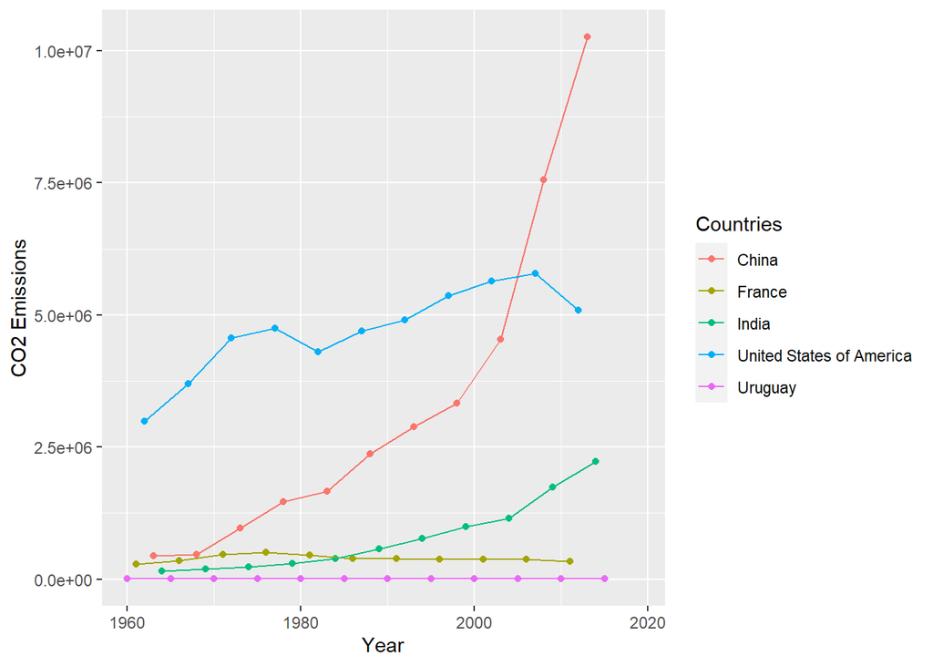

### **Question 3**

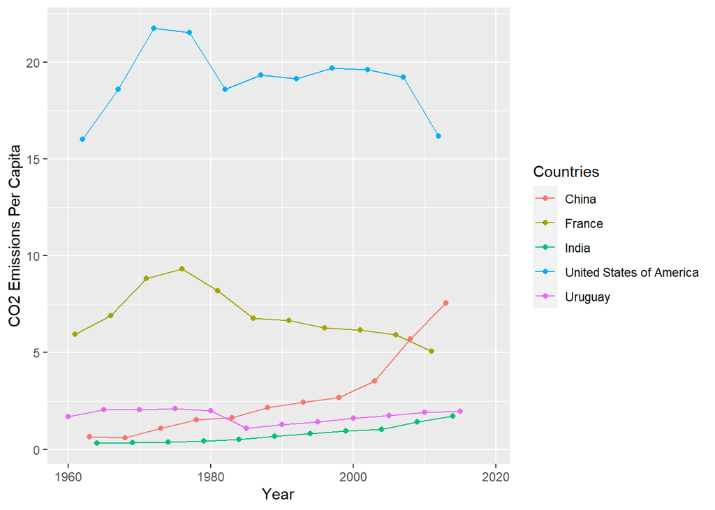

### **Question 4**

```
## # A tibble: 11 × 3
## # Groups:   region [6]
##    region      time avgCo2_PC
##    <chr>      <int>     <dbl>
##  1 ""          2016    19.4
##  2 "Africa"    1960     0.291
##  3 "Africa"    2016     1.20
##  4 "Americas"  1960     7.15
##  5 "Americas"  2016     4.80
##  6 "Asia"      1960     1.74
##  7 "Asia"      2016     6.47
##  8 "Europe"    1960     5.77
##  9 "Europe"    2016     6.64
## 10 "Oceania"   1960     2.73
## 11 "Oceania"   2016     4.57
```

### **Question 5**

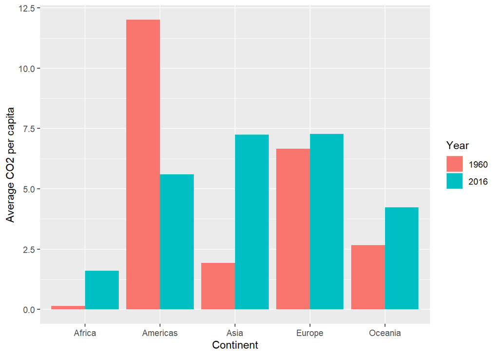

### **Question 6**

```
## # A tibble: 4 × 3
## # Groups:   name, region [4]
##   name                  region         n
##   <chr>                 <chr>      <dbl>
## 1 "Qatar"               "Asia"      38.9
## 2 ""                    ""          33.8
## 3 "Trinidad and Tobago" "Americas"  31.8
## 4 "Kuwait"              "Asia"      25.0
```

```
## # A tibble: 3 × 3
## # Groups:   name, region [3]
##   name                              region      n
##   <chr>                             <chr>   <dbl>
## 1 Burundi                           Africa 0.0472
## 2 Somalia                           Africa 0.0455
## 3 Congo, Democratic Republic of the Africa 0.0256
```

The 3 largest CO2 emitters in 2019 are Qatar, Trindad and Toabago, and Kuwait. The 3 smallest CO2 emitters in 2019 are Burundi, Somalia, and the Democratic Republic of Congo

## GDP per capita

### **Question 1**

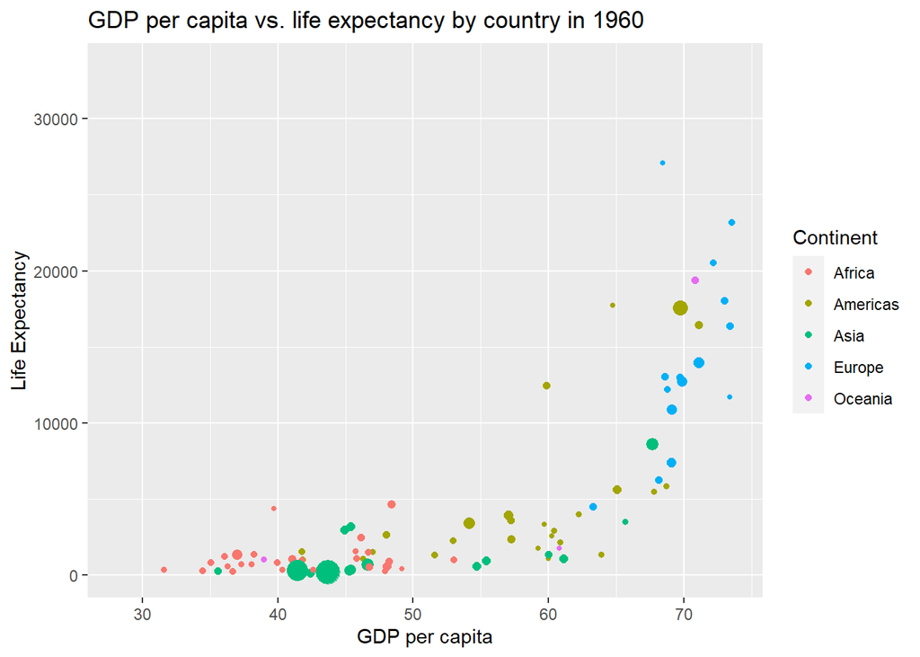

For most countries besides Africa, the higher the GDP per capita is the more the Life Expectancy increases

### **Question 2**

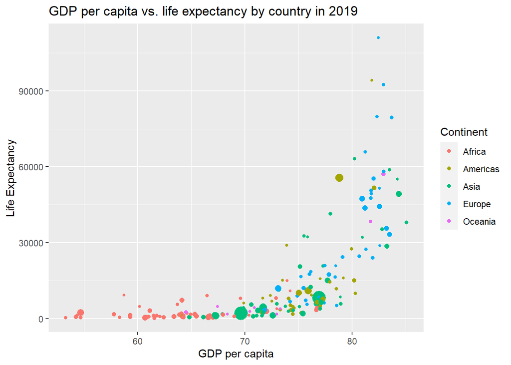

### **Question 4**

```
## # A tibble: 10 × 3
## # Groups:   region [5]
##    region    time lifeExpectancy_avg
##    <chr>    <int>              <dbl>
##  1 Africa    1960               41.4
##  2 Americas  1960               58.8
##  3 Asia      1960               53.2
##  4 Europe    1960               67.5
##  5 Oceania   1960               54.6
##  6 Africa    2019               63.9
##  7 Americas  2019               76.0
##  8 Asia      2019               75.0
##  9 Europe    2019               78.6
## 10 Oceania   2019               72.3
```

The results do fit what you see in the figures

### **Question 5**

```
## # A tibble: 5 × 2
##   region   lifeExpectancy_growth_avg
##   <chr>                        <dbl>
## 1 Africa                      0.0438
## 2 Americas                    0.111
## 3 Asia                        0.0186
## 4 Europe                      0.0279
## 5 Oceania                     0.211
```

### **Question 6**

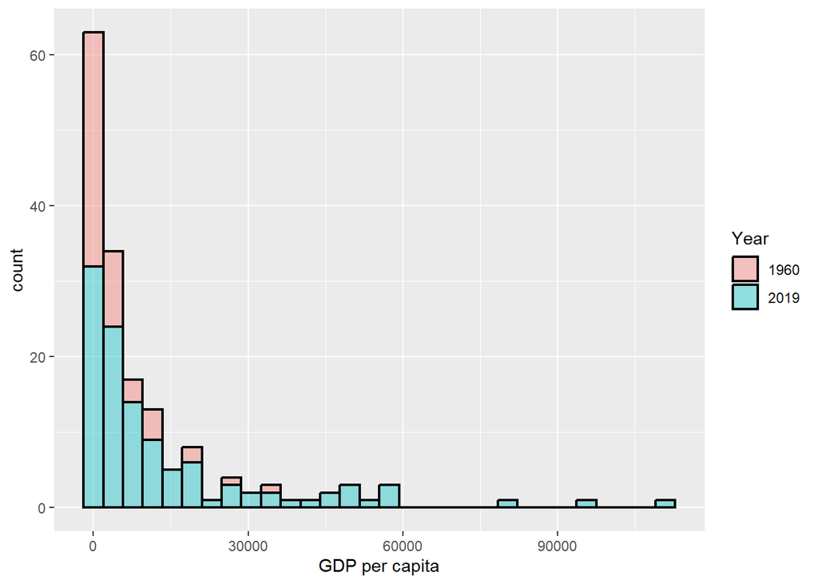

### **Question 7**

```
##                       name rank
## 1 United States of America   17
```

```
##                       name rank
## 1 United States of America   46
```

The rank of the US in 1960 was 17, and the rank of the US of the US in 2019 was 46